# Hemoglobina

Autor/a

Mario Camacho

Fecha de publicación

08 marzo 2025

**Stakeholder:** Jose L Merino Rivas **Centro:** Hospital del Henares  
**Fecha última modificación:** 23 abril 2026

## Distribución de la hemogoblina

**Implicación clínica**

Distribución de la hemogoblina en cada mes de control en cada una de las ramas de aleatorización (Venofer y Ferinject).

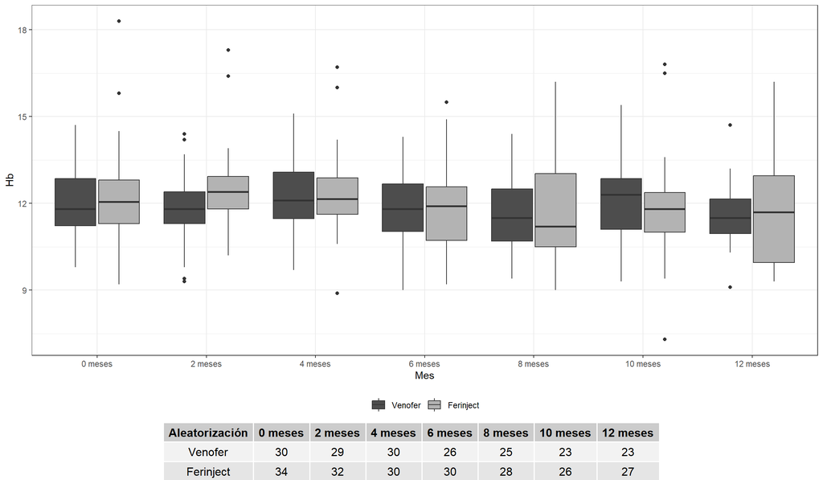

En la siguiente tabla se muestra, para cada mes de control y grupo de aleatorización:  
- Número de pacientes incluidos en el mes de control.  
- Número de pacientes con muestra de Hemoglobina recogida.  
- Valor medio, desviación típica, mediana, Q1 y Q3 de la hemogoblina

Nota:  
- Para comparar las diferencias de hemoglobina entre las ramas de aleatorización en un mismo momento temporal: ordenar la tabla por la columna Mes.  
- Para visualizar la evolución temporal de la hemoglobina dentro de cada rama: ordenar la tabla por la columna Aleatorización.

Distribución de la hemogoblina por mes

| Mes | Aleatorización | n | Pacientes con hemoglobina basal | media | sd | mediana | Q1 | Q3 |
| --- | --- | --- | --- | --- | --- | --- | --- | --- |
| 0 meses | Venofer | 30 | 30 | 12 | 1.2 | 11.8 | 11.2 | 12.8 |
| 0 meses | Ferinject | 34 | 34 | 12.3 | 1.7 | 12.1 | 11.3 | 12.8 |
| 2 meses | Venofer | 30 | 29 | 11.8 | 1.3 | 11.8 | 11.3 | 12.4 |
| 2 meses | Ferinject | 34 | 32 | 12.6 | 1.5 | 12.4 | 11.8 | 12.9 |
| 4 meses | Venofer | 30 | 30 | 12.2 | 1.2 | 12.1 | 11.5 | 13.1 |
| 4 meses | Ferinject | 31 | 30 | 12.4 | 1.5 | 12.1 | 11.6 | 12.9 |
| 6 meses | Venofer | 27 | 26 | 11.8 | 1.1 | 11.8 | 11 | 12.7 |
| 6 meses | Ferinject | 30 | 30 | 11.9 | 1.5 | 11.9 | 10.7 | 12.6 |
| 8 meses | Venofer | 26 | 25 | 11.7 | 1.3 | 11.5 | 10.7 | 12.5 |
| 8 meses | Ferinject | 29 | 28 | 11.6 | 1.8 | 11.2 | 10.5 | 13 |

[output cut: 4 more lines]

Distribución de la hemogoblina basal según el tiempo hasta el estudio

| Tiempo hasta inicio estudio | Aleatorización | n | Pacientes con hemoglobina basal | media | sd | mediana | Q1 | Q3 |
| --- | --- | --- | --- | --- | --- | --- | --- | --- |
| < 1 año | Venofer | 4 | 4 | 13.2 | 1.3 | 13.6 | 12.6 | 14.1 |
| < 1 año | Ferinject | 7 | 7 | 11.8 | 1 | 11.8 | 11.1 | 12.6 |
| 1-2 años | Venofer | 7 | 7 | 11.9 | 0.8 | 11.8 | 11.5 | 11.9 |
| 1-2 años | Ferinject | 7 | 7 | 12.1 | 1.1 | 12.6 | 11.4 | 12.9 |
| 2-3 años | Venofer | 4 | 4 | 11.6 | 1.4 | 11.6 | 10.9 | 12.2 |
| 2-3 años | Ferinject | 5 | 5 | 12.5 | 1.2 | 12.6 | 12.1 | 12.8 |
| 3-4 años | Venofer | 1 | 1 | 11.6 | NA | 11.6 | 11.6 | 11.6 |
| 3-4 años | Ferinject | 5 | 5 | 13.2 | 1.9 | 12.8 | 11.7 | 14.5 |
| >= 4 años | Venofer | 14 | 14 | 11.8 | 1.3 | 11.7 | 10.9 | 12.4 |
| >= 4 años | Ferinject | 10 | 10 | 12.1 | 2.4 | 11.7 | 11.3 | 12.4 |

### Niveles basales de la hemogoblina en cada rama

**Implicación clínica**

**Requisito.**

Para contrastar si una rama de la aleatorización ofrece mejores resultados que la otra rama, debemos confirmar que ambas ramas parten del mismo punto. ¿El nivel de hemogoblina basal es igual para cada rama de la aleatorización? En caso de no serlo, las diferencias entre grupos en los controles puede deberse a que no partían ambos del mismo punto.

**Implicación clínica**

El siguiente test muestra que **no hay evidencia suficiente para confirmar que el nivel de la hemogoblina basal en ambos grupos es diferente (p = 0.4122)**. La diferencia estimada de medias es -0.30 (Venofer algo menor). Esta diferencias no es estadísticamente significativa.

```
##
##  Welch Two Sample t-test
##
## data:  Hb by Aleatorización
## t = -0.82567, df = 60.257, p-value = 0.4122
## alternative hypothesis: true difference in means between group Venofer and group Ferinject is not equal to 0
## 95 percent confidence interval:
##  -1.0347802  0.4300743
## sample estimates:
##   mean in group Venofer mean in group Ferinject
##                11.98000                12.28235
```

Gráficamente:

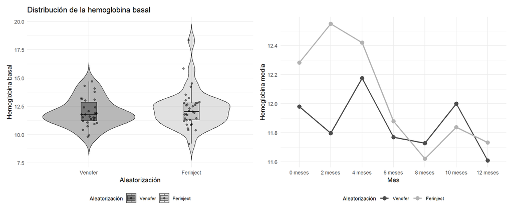

## Distribución del cambio de la hemoglobina respecto el valor basal

Distribución de la diferencia por mes de la hemoglobina respecto al nivel basal para cada una de las dos ramas (Venofer y Ferinject).

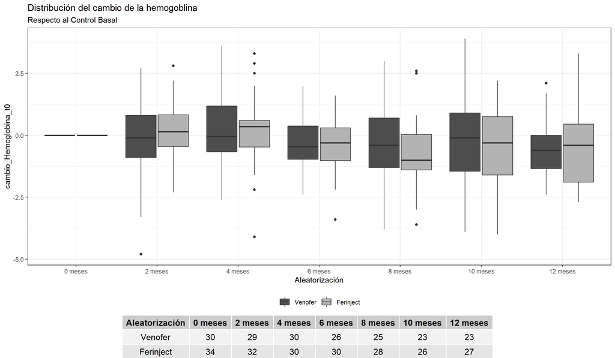

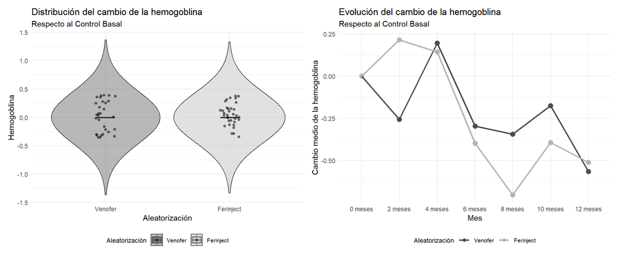

## Distribución del cambio de la hemoglobina respecto el control anterior

Distribución de la diferencia por mes de la hemoglobina respecto al control anterior para cada una de las dos ramas (Venofer y Ferinject).

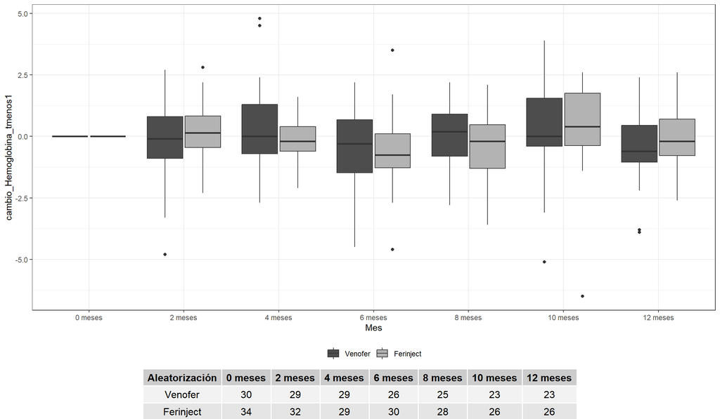

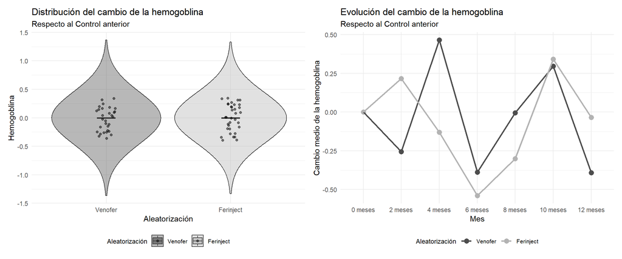

## Niveles óptimos

**Implicación clínica**

Los niveles óptimos de hemoglobina se sitúan entre 10 y 12 g/dL.

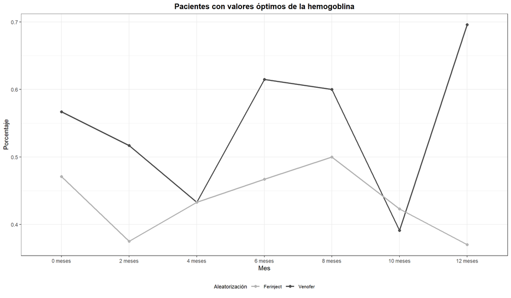

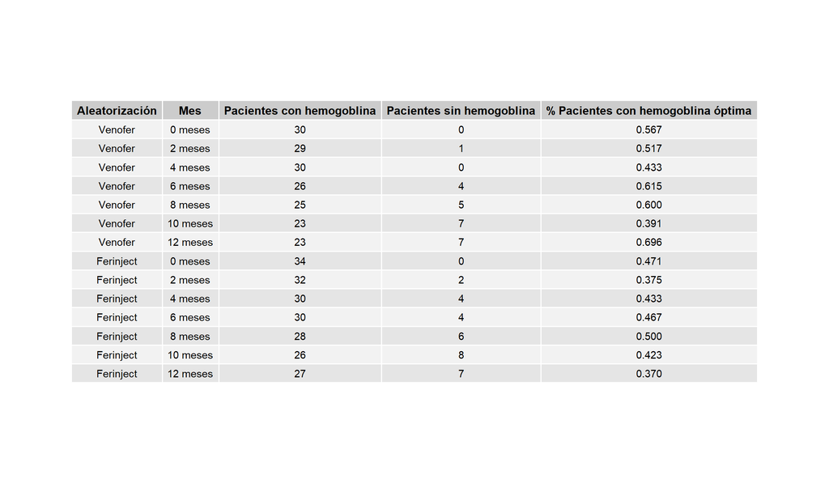

**Tabla para buscar qué pacientes están en rango óptimo o no óptimo por mes.**

| Paciente | Aleatorización | 0 meses | 2 meses | 4 meses | 6 meses | 8 meses | 10 meses | 12 meses |
| --- | --- | --- | --- | --- | --- | --- | --- | --- |
| 1 | Ferinject | 0 | 0 | 1 | 0 | 0 | 1 | 1 |
| 2 | Venofer | 0 | 1 | 1 | 0 | 0 | 0 | 1 |
| 3 | Ferinject | 0 | 1 | 1 | 0 | 1 | 1 | 1 |
| 4 | Ferinject | 1 | 1 | 1 | 1 | 1 | 1 | 1 |
| 5 | Ferinject | 1 | NA | 1 | 0 | 1 | 1 | 0 |
| 6 | Ferinject | 0 | 0 | NA | NA | NA | NA | NA |
| 7 | Ferinject | 0 | 0 | 0 | 0 | 0 | 0 | 0 |
| 8 | Ferinject | 0 | 0 | 0 | 0 | 1 | 1 | 1 |
| 9 | Ferinject | 0 | 0 | NA | NA | NA | NA | NA |
| 10 | Venofer | 1 | 0 | 0 | 1 | 0 | 1 | 1 |

[output cut: 54 more lines]

1: valor óptimo. 0: valor no óptimo. NA: sin ferritina